# LET’S PRACTICE Geovisualization and Spatial Analysis

Kim Antunez & Timothée Giraud

Massive spatial data: challenges in acquisition, treatment and use for territories

# 1 Exercice 1 : Manipuler les objets sf et des data.frames associés

1. Charger la couche cartographique des iris du département 31 “iris_31.rds” dans R. Est-ce que la fonction `sf::st_read` fonctionnerait également ? Pourquoi ?

**CLUES**

Utilisez la fonction `readRDS`.

```r
library(sf)
iris_31 <- readRDS("data/iris_31.rds")
# iris_31 <- st_read("data/iris_31.rds")
# Cela ne fonctionne pas car il ne s'agit pas d'un shapefile mais d'un fichier déjà mis au format R. Il suffit
# alors simplement de le charger avec la fonction readRDS.
```

2. Afficher simplement le fond de carte du département 31 avec l’instruction `plot(iris_31)`. Que remarquez-vous ?

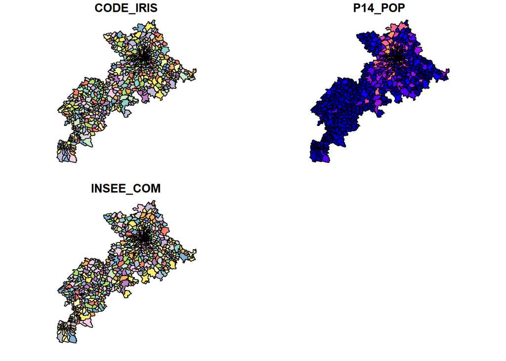

```r
plot(iris_31)
```

```r
# On remarque que R effectue un graphique par variable présent dans le fichier sf, ici 3.
```

3. Quel est le rôle de la fonction `sf::st_geometry` ? Quelle solution proposez-vous alors ?

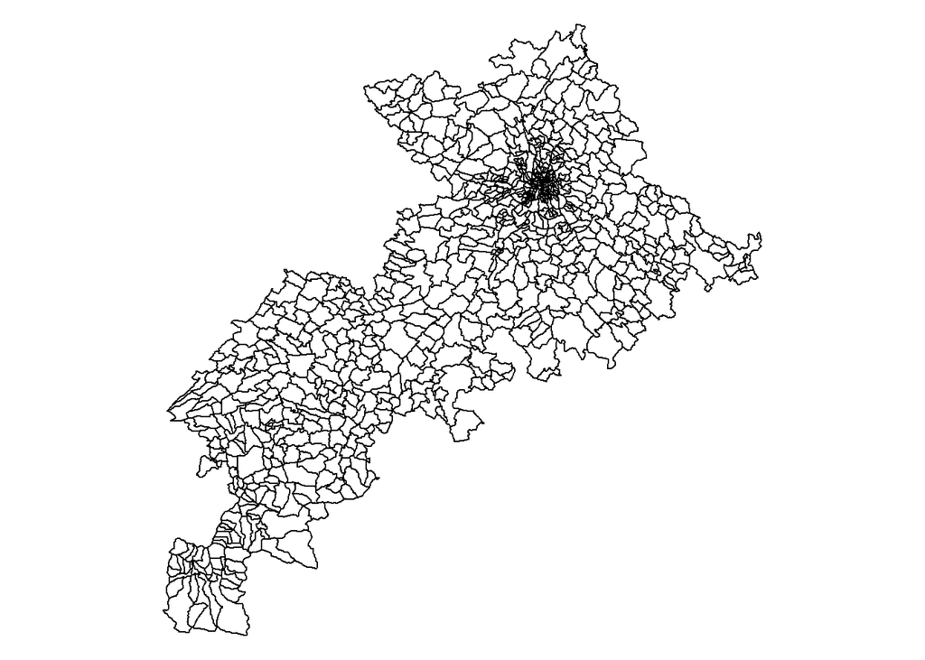

```r
# ?sf::st_geometry
# Cette fonction permet d'isoler les informations de l'objet sf relatives à sa géométrie et d'ainsi mettre de côté les autres variables ici CODE_IRIS, P14_POP et INSEE_COM
plot(st_geometry(iris_31))
```

4. En quelle projection est la couche cartographique ? Cartographiez-la dans une autre projection.

**CLUES**

Utilisez la fonction `sf::st_crs` pour deviner la projection et `sf::st_transform` pour changer la projection.

```r
#?st_crs
st_crs(iris_31)
```

```
Coordinate Reference System:
  EPSG: 2154
  proj4string: "+proj=lcc +lat_1=49 +lat_2=44 +lat_0=46.5 +lon_0=3 +x_0=700000 +y_0=6600000 +ellps=GRS80 +towgs84=0,0,0,0,0,0,0 +units=m +no_defs"
```

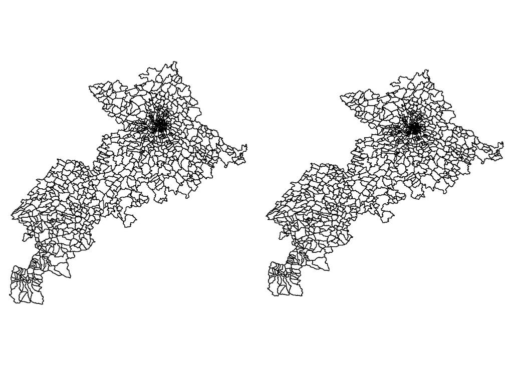

```r
par(mar = c(0,0,0,0), mfrow = c(1,2))
plot(st_geometry(iris_31))
plot(st_transform(st_geometry(iris_31), crs="+proj=aeqd +lat_0=90 +lon_0=0"))
```

5. A partir de la couche “iris_31”, créez une couche cartographique appelée “com_31” qui correspond aux communes du département 31. Gardez également dans cette nouvelle couche les informations sur la population présente dans chaque commune.

Info : La couche cartographique “iris_31”" contient les codes communes dans sa variable INSEE_COM et la population municipale de 2014 dans sa variable P14_POP.

**CLUES**

Utilisez les fonctions classiques du package dplyr `select`, `group_by` et `summarize` qui s’appliquent aussi sur des objets de type sf.

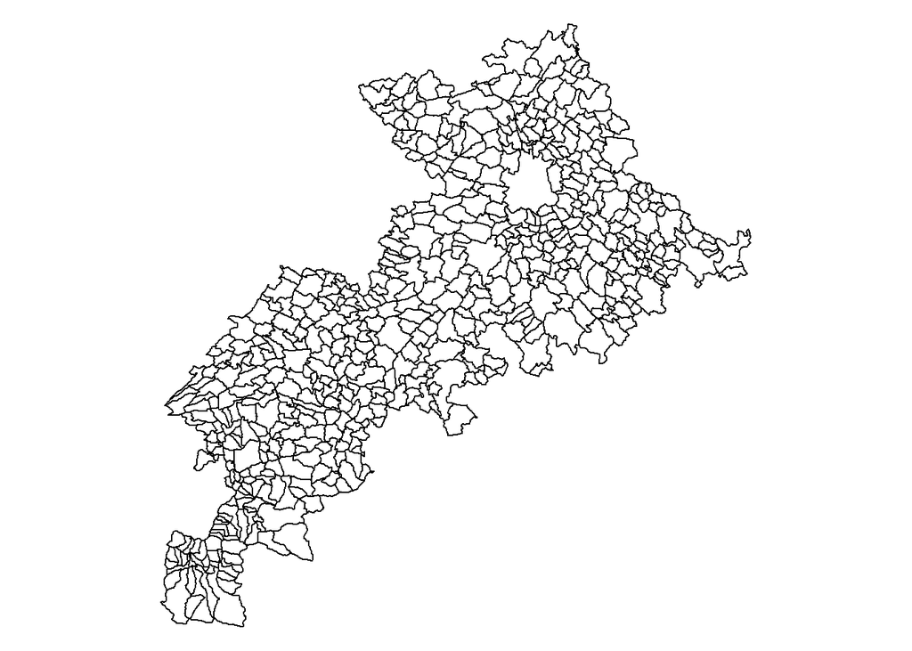

```r
library(dplyr)
com_31 <- iris_31 %>%
  select(INSEE_COM,P14_POP) %>%
  group_by(INSEE_COM) %>%
  summarize(P14_POP= sum(P14_POP))
plot(st_geometry(com_31))
```

```r
#Timothée : peut-on le faire aussi avec st_union ou st_union ne permet pas le group_by ?
```

6. En utilisant les données contenues dans “sir_31”, ajoutez à cette couche le nombre de restaurants par commune. Info : Le code commune n’est pas présent dans la base “sir_31”. Pour l’obtenir, il faut créer une variable INSEE_COM (5 chiffres) qui contatène les variables DEPET (2 chiffres) et COMET (3 chiffres).

```r
sir_31 <- readRDS("data/sir_31.rds")

com_31 <- left_join(com_31,
                    sir_31 %>%
  mutate(INSEE_COM=paste0(DEPET,COMET)) %>%
  group_by(INSEE_COM) %>%
   summarize(nb_of_rest= n()) %>%
  st_set_geometry(NULL),
                    by=c("INSEE_COM"="INSEE_COM")
) %>%
  mutate(nb_of_rest=ifelse(is.na(nb_of_rest),0,nb_of_rest))
```

7. Agrégez toutes les informations présentes dans “com_31” au niveau des intercommunalités (EPCI). Info : Il faut utiliser la table de passage “table_MAUP.rds” pour avoir une correspondance entre le code communal (CODGEO) et le code de l’intercommunalité (EPCI).

```r
table_passage <- readRDS("data/table_MAUP.rds") %>%
  select(CODGEO,EPCI)

epci_31  <- com_31 %>%
  left_join(table_passage,by=c("INSEE_COM"="CODGEO")) %>%
  group_by(EPCI) %>%
  summarize(P14_POP=sum(P14_POP),nb_of_rest= sum(nb_of_rest))
# Timothée : peut-on le faire aussi avec st_union ou st_union ne permet pas le group_by ?
```

Info : On peut remarquer que le nombre de restaurants est très faible voire nul dans la plupart des communes.

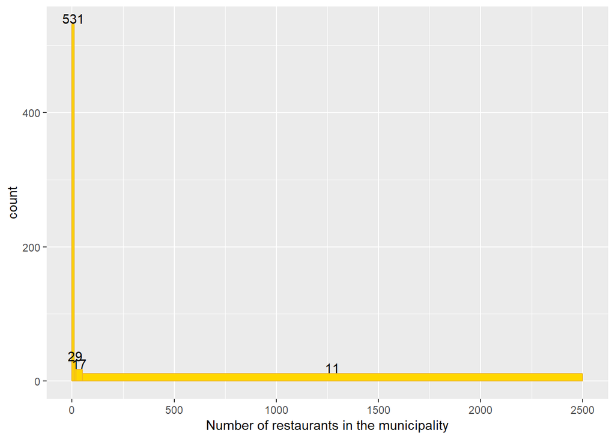

```r
library(ggplot2)
histo <- ggplot(com_31 , aes(x = nb_of_rest)) +
    stat_bin(breaks=c(0,10,20,50,2500),colour = "goldenrod2", fill = "gold1") +
    scale_x_continuous(name = "Number of restaurants in the municipality") +
    stat_bin(breaks=c(0,10,20,50,2500), geom="text", aes(label=ifelse(..count..!=0,..count..,""), vjust=-0.1))
plot(histo)
```

```r
epci_31 %>% st_set_geometry(NULL) %>% arrange(desc(nb_of_rest))
```

```
# A tibble: 19 x 3
   EPCI      P14_POP nb_of_rest
   <chr>       <int>      <dbl>
 1 243100518  746928       3249
 2 200068641  116721        354
 3 243100633   73824        196
 4 200072643   44120        143
 5 200072635   15715         88
 6 200068815   34195         86
 7 200071298   37990         86
 8 243100781   37836         76
 9 200071314   32108         74
10 200066819   29224         73
11 200068807   30274         61
12 200034957   25102         60
13 243100567   13178         60
14 200073146   17709         44
15 243100732   20787         37
16 243100773   16668         37
17 243100815   19308         34
18 200023620    5368          7
19 200034023     620          0
```

8. On va donc vouloir cartographier le nombre de restaurants au niveau communal si son EPCI contient plus de 100 restaurants et au niveau intercommunal si l’EPCI contient moins de 100 restaurants. Créez une couche cartographique qui réponde à ce besoin.

**CLUES**

Commencez par créer les couches EPCI_less100 et COM_more100 qui correspondent respectivement aux EPCI qui contiennent moins de 100 restaurants et aux communes qui appartiennent à un EPCI contenant plus de 100 restaurants. Puis, utilisez l’instruction `do.call(rbind, list(EPCI_less100,COM_more100))` pour les fusionner.

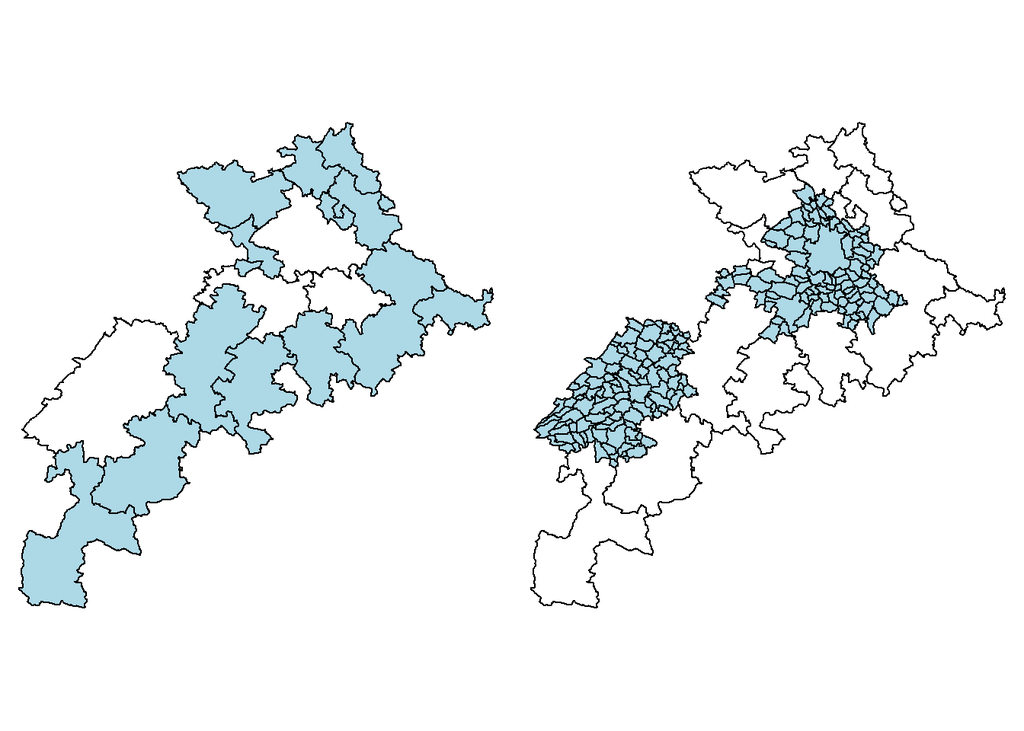

```r
EPCI_less100 <- epci_31 %>% filter(nb_of_rest < 100) %>%
  setNames(c("territory","P14_POP","nb_of_rest","geometry"))

COM_more100 <- left_join(com_31,table_passage,by=c("INSEE_COM"="CODGEO")) %>%
  filter(!EPCI%in%EPCI_less100$territory) %>%
  select(-EPCI) %>%
  setNames(c("territory","P14_POP","nb_of_rest","geometry"))

par(mar = c(0,0,0,0), mfrow = c(1,2))
plot(st_geometry(epci_31))
plot(st_geometry(EPCI_less100), col="lightblue",add=TRUE)
plot(st_geometry(epci_31))
plot(st_geometry(COM_more100), col="lightblue",add=TRUE)
```

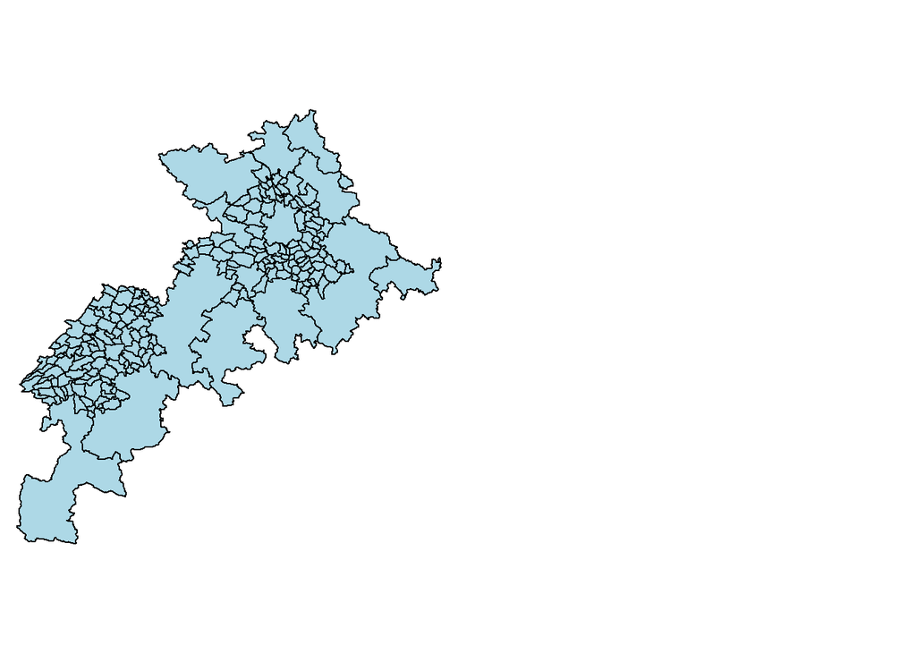

```r
mix_31 <- do.call(rbind, list(EPCI_less100,COM_more100))

plot(st_geometry(mix_31), col="lightblue")
```

9. A l’aide du package {cartography}, ajoutez simplement à cette carte un rond proportionnel au nombre de restaurants sur chacun de ces territoires.

**CLUES**

C’est la fonction `propSymbolsLayer` qui permet de dessiner des ronds proportionnels.

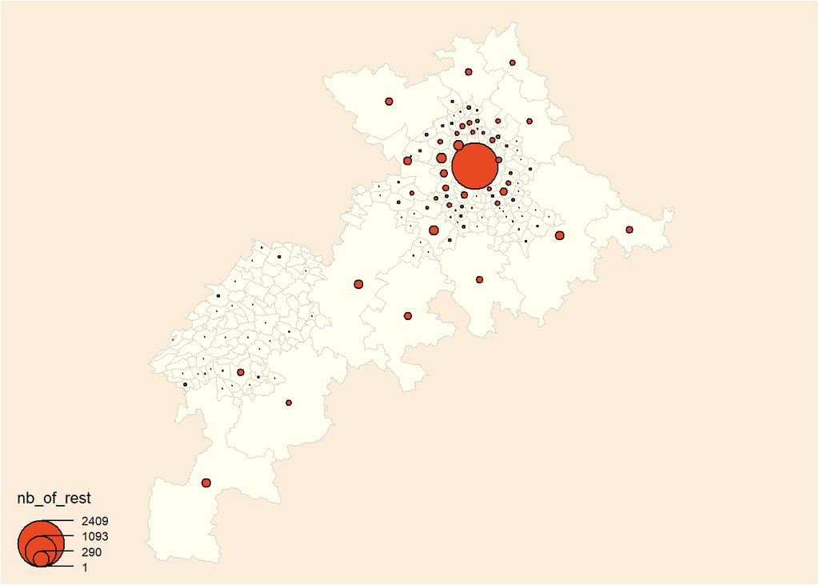

```r
library(cartography)
plot(st_geometry(mix_31), col = "ivory1", border = "ivory3",lwd =0.5,bg = "#FBEDDA")
propSymbolsLayer(mix_31, var = "nb_of_rest", inches = 0.2)
```

# 2 Exercice 2 : Cartographie statique et interactive

# 3 Exercice 3 : cartogramme

Pour les exos de la fin, une idée pourrait être de faire plusieurs exercices courts à la fin (pour les plus avancés ?) sur des choses marrantes à faire, indépendamment de ce que l’on montrerait en “cours”. J’ai pensé à quelques idées ici…

1. Réaliser un cartogramme du département 31 au niveau intercommunal proportionnellement aux nombres de restaurants (données SIRENE).

```r
#library(cartogram)
#cartogramme <- cartogram_cont(epci_31, "nb_of_rest", itermax = 5, maxSizeError = 1)
# Erreur... Si tu comprends pourquoi Timothée...
```

# 4 Exercice 4 : carte tricolore

1. Réaliser une carte tricolore qui représente les iris de Toulouse en fonction de si elles sont plutôt dotées en restaurants, cafés ou fast foods (données OSM)

[figure not shown]

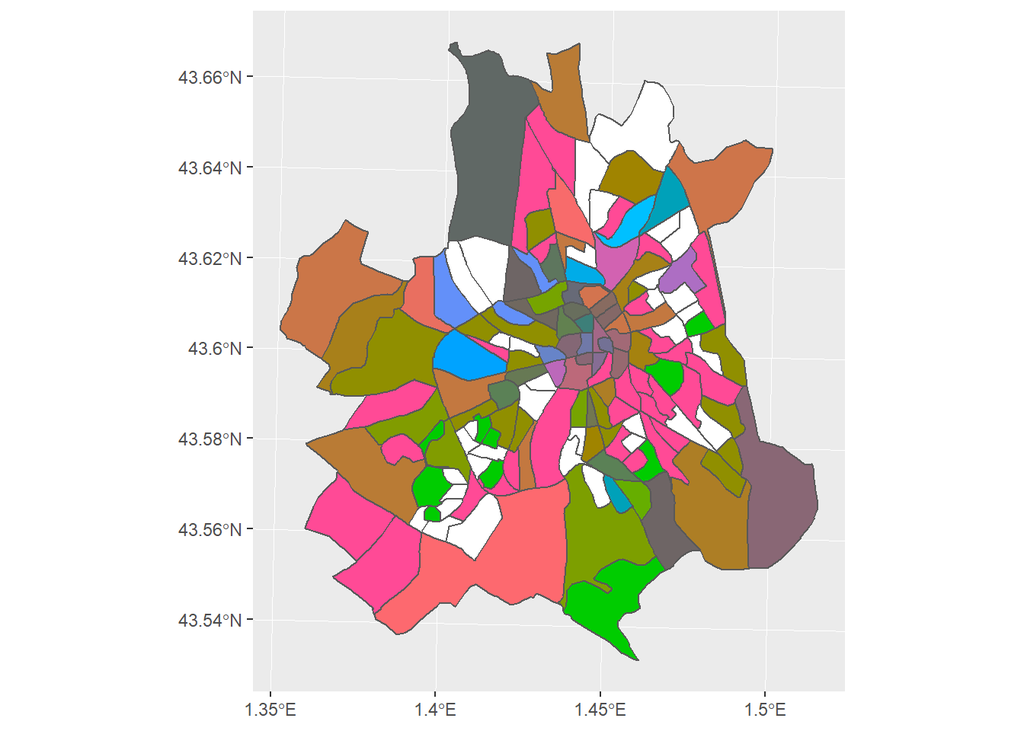

```r
bdd <- readRDS("data/osm_31.rds") %>%
  filter(INSEE_COM=="31555")

bdd_restaurant <- bdd %>% filter(amenity=="restaurant") %>%
  group_by(CODE_IRIS) %>%
   summarize(restaurant= n()) %>%
  st_set_geometry(NULL)

bdd_fast_food <- bdd %>% filter(amenity=="fast_food") %>%
  group_by(CODE_IRIS) %>%
   summarize(fast_food= n()) %>%
  st_set_geometry(NULL)

bdd_cafe <- bdd %>% filter(amenity=="cafe") %>%
  group_by(CODE_IRIS) %>%
   summarize(cafe= n()) %>%
  st_set_geometry(NULL)

couche_carto <- left_join(iris_31 %>%  filter(INSEE_COM=="31555"),
                          bdd_restaurant,
                          by=c("CODE_IRIS"="CODE_IRIS")
) %>%
left_join(bdd_fast_food,by=c("CODE_IRIS"="CODE_IRIS")) %>%
left_join(bdd_cafe,by=c("CODE_IRIS"="CODE_IRIS")) %>%
  replace(is.na(.),0) %>%
  mutate(part_restaurant = restaurant / (restaurant + fast_food + cafe),
         part_fast_food = fast_food / (restaurant + fast_food + cafe),
         part_cafe = cafe / (restaurant + fast_food + cafe)
         )

# devtools::install_version("ggplot2", version = "2.2.1", repos = "http://cran.us.r-project.org")
# The recent update of ggplot2 to version 3.0.0 caused ggtern to break and in turn tricolore. We're working on a fix.In the meantime, in order to use tricolore you must revert to ggplot version 2.2.1.
# library(tricolore)
# tric <- Tricolore(couche_carto %>% st_set_geometry(NULL), 'part_restaurant', 'part_fast_food', 'part_cafe', center = NA)
#saveRDS(object = tric, file = "data/tric.rds")
tric <- readRDS("data/tric.rds")

# ancienne version ggplot2 issue à régler
#tric$legend


couche_carto <- bind_cols(couche_carto,tric$hexsrgb %>% as_data_frame() %>% replace(is.na(.),"#FFFFFFFF"))

library(ggplot2)
q <- ggplot(couche_carto) +
    geom_sf(aes(fill = value)) +
  scale_fill_identity()

q
```

```r
####### AVEC SP
# couche_carto_sp <- merge(fortify(
#   rgeos::gBuffer(sf:::as_Spatial(couche_carto),
#   width = 0, byid = TRUE), region = "CODE_IRIS"), couche_carto %>% st_set_geometry(NULL), by.x = "id",
#   by.y = "CODE_IRIS", all.x = TRUE)

# q <- ggplot(couche_carto_sp) +
#   geom_polygon(aes(long, lat, group = group, fill = value),
#                data = couche_carto_sp) +
#   scale_fill_identity() +
#   coord_fixed()
  # + xlim(c(565000,590000)) +
  # annotation_custom(
  #   ggplotGrob(
  #     tric$legend +
  #       theme(plot.background = element_rect(fill = NA, color = NA))
  #   ),
  #   xmin = 575000, xmax = 595000, ymin = 6274000, ymax = 6284000)
```